# Risk Factor Analysis

## Outcome Variable

**Outcome Variable:** ever_stunted

## Predictor Variables

**Intervention Variable:** nrooms

**Adjustment Set:**

unadjusted

## Stratifying Variables

The analysis was stratified on these variable(s):

- agecat
- studyid
- country

## Data Summary

| agecat | studyid | country | nrooms | ever_stunted | n_cell | n |
| --- | --- | --- | --- | --- | --- | --- |
| 0-24 months | CMC-V-BCS-2002 | INDIA | 4+ | 0 | 2 | 373 |
| 0-24 months | CMC-V-BCS-2002 | INDIA | 4+ | 1 | 12 | 373 |
| 0-24 months | CMC-V-BCS-2002 | INDIA | 1 | 0 | 11 | 373 |
| 0-24 months | CMC-V-BCS-2002 | INDIA | 1 | 1 | 191 | 373 |
| 0-24 months | CMC-V-BCS-2002 | INDIA | 2 | 0 | 8 | 373 |
| 0-24 months | CMC-V-BCS-2002 | INDIA | 2 | 1 | 98 | 373 |
| 0-24 months | CMC-V-BCS-2002 | INDIA | 3 | 0 | 7 | 373 |
| 0-24 months | CMC-V-BCS-2002 | INDIA | 3 | 1 | 44 | 373 |
| 0-24 months | COHORTS | INDIA | 4+ | 0 | 87 | 5374 |
| 0-24 months | COHORTS | INDIA | 4+ | 1 | 19 | 5374 |
| 0-24 months | COHORTS | INDIA | 1 | 0 | 1943 | 5374 |
| 0-24 months | COHORTS | INDIA | 1 | 1 | 1576 | 5374 |
| 0-24 months | COHORTS | INDIA | 2 | 0 | 1116 | 5374 |
| 0-24 months | COHORTS | INDIA | 2 | 1 | 438 | 5374 |
| 0-24 months | COHORTS | INDIA | 3 | 0 | 143 | 5374 |
| 0-24 months | COHORTS | INDIA | 3 | 1 | 52 | 5374 |
| 0-24 months | CONTENT | PERU | 4+ | 0 | 62 | 215 |
| 0-24 months | CONTENT | PERU | 4+ | 1 | 16 | 215 |
| 0-24 months | CONTENT | PERU | 1 | 0 | 32 | 215 |
| 0-24 months | CONTENT | PERU | 1 | 1 | 12 | 215 |
| 0-24 months | CONTENT | PERU | 2 | 0 | 39 | 215 |
| 0-24 months | CONTENT | PERU | 2 | 1 | 15 | 215 |
| 0-24 months | CONTENT | PERU | 3 | 0 | 29 | 215 |
| 0-24 months | CONTENT | PERU | 3 | 1 | 10 | 215 |
| 0-24 months | GMS-Nepal | NEPAL | 4+ | 0 | 113 | 698 |
| 0-24 months | GMS-Nepal | NEPAL | 4+ | 1 | 210 | 698 |
| 0-24 months | GMS-Nepal | NEPAL | 1 | 0 | 20 | 698 |
| 0-24 months | GMS-Nepal | NEPAL | 1 | 1 | 29 | 698 |
| 0-24 months | GMS-Nepal | NEPAL | 2 | 0 | 49 | 698 |
| 0-24 months | GMS-Nepal | NEPAL | 2 | 1 | 96 | 698 |

[output cut: 306 more lines]

The following strata were considered:

- agecat: 0-24 months, studyid: CMC-V-BCS-2002, country: INDIA
- agecat: 0-24 months, studyid: COHORTS, country: INDIA
- agecat: 0-24 months, studyid: CONTENT, country: PERU
- agecat: 0-24 months, studyid: GMS-Nepal, country: NEPAL
- agecat: 0-24 months, studyid: IRC, country: INDIA
- agecat: 0-24 months, studyid: MAL-ED, country: BANGLADESH
- agecat: 0-24 months, studyid: MAL-ED, country: BRAZIL
- agecat: 0-24 months, studyid: MAL-ED, country: INDIA
- agecat: 0-24 months, studyid: MAL-ED, country: NEPAL
- agecat: 0-24 months, studyid: MAL-ED, country: PERU
- agecat: 0-24 months, studyid: MAL-ED, country: SOUTH AFRICA
- agecat: 0-24 months, studyid: MAL-ED, country: TANZANIA, UNITED REPUBLIC OF
- agecat: 0-24 months, studyid: NIH-Crypto, country: BANGLADESH
- agecat: 0-24 months, studyid: PROVIDE, country: BANGLADESH
- agecat: 0-6 months, studyid: CMC-V-BCS-2002, country: INDIA
- agecat: 0-6 months, studyid: COHORTS, country: INDIA
- agecat: 0-6 months, studyid: CONTENT, country: PERU
- agecat: 0-6 months, studyid: GMS-Nepal, country: NEPAL
- agecat: 0-6 months, studyid: IRC, country: INDIA
- agecat: 0-6 months, studyid: MAL-ED, country: BANGLADESH
- agecat: 0-6 months, studyid: MAL-ED, country: BRAZIL
- agecat: 0-6 months, studyid: MAL-ED, country: INDIA
- agecat: 0-6 months, studyid: MAL-ED, country: NEPAL
- agecat: 0-6 months, studyid: MAL-ED, country: PERU
- agecat: 0-6 months, studyid: MAL-ED, country: SOUTH AFRICA
- agecat: 0-6 months, studyid: MAL-ED, country: TANZANIA, UNITED REPUBLIC OF
- agecat: 0-6 months, studyid: NIH-Crypto, country: BANGLADESH
- agecat: 0-6 months, studyid: PROVIDE, country: BANGLADESH
- agecat: 6-24 months, studyid: CMC-V-BCS-2002, country: INDIA
- agecat: 6-24 months, studyid: COHORTS, country: INDIA
- agecat: 6-24 months, studyid: CONTENT, country: PERU
- agecat: 6-24 months, studyid: GMS-Nepal, country: NEPAL
- agecat: 6-24 months, studyid: IRC, country: INDIA
- agecat: 6-24 months, studyid: MAL-ED, country: BANGLADESH
- agecat: 6-24 months, studyid: MAL-ED, country: BRAZIL
- agecat: 6-24 months, studyid: MAL-ED, country: INDIA
- agecat: 6-24 months, studyid: MAL-ED, country: NEPAL
- agecat: 6-24 months, studyid: MAL-ED, country: PERU
- agecat: 6-24 months, studyid: MAL-ED, country: SOUTH AFRICA
- agecat: 6-24 months, studyid: MAL-ED, country: TANZANIA, UNITED REPUBLIC OF
- agecat: 6-24 months, studyid: NIH-Crypto, country: BANGLADESH
- agecat: 6-24 months, studyid: PROVIDE, country: BANGLADESH

### Dropped Strata

Some strata were dropped due to rare outcomes:

- agecat: 0-24 months, studyid: CMC-V-BCS-2002, country: INDIA
- agecat: 0-24 months, studyid: IRC, country: INDIA
- agecat: 0-24 months, studyid: MAL-ED, country: BANGLADESH
- agecat: 0-24 months, studyid: MAL-ED, country: BRAZIL
- agecat: 0-24 months, studyid: MAL-ED, country: PERU
- agecat: 0-6 months, studyid: CONTENT, country: PERU
- agecat: 0-6 months, studyid: MAL-ED, country: BANGLADESH
- agecat: 0-6 months, studyid: MAL-ED, country: BRAZIL
- agecat: 0-6 months, studyid: MAL-ED, country: NEPAL
- agecat: 0-6 months, studyid: PROVIDE, country: BANGLADESH
- agecat: 6-24 months, studyid: CMC-V-BCS-2002, country: INDIA
- agecat: 6-24 months, studyid: CONTENT, country: PERU
- agecat: 6-24 months, studyid: IRC, country: INDIA
- agecat: 6-24 months, studyid: MAL-ED, country: BANGLADESH
- agecat: 6-24 months, studyid: MAL-ED, country: BRAZIL
- agecat: 6-24 months, studyid: MAL-ED, country: NEPAL
- agecat: 6-24 months, studyid: MAL-ED, country: PERU
- agecat: 6-24 months, studyid: MAL-ED, country: SOUTH AFRICA
- agecat: 6-24 months, studyid: MAL-ED, country: TANZANIA, UNITED REPUBLIC OF
- agecat: 6-24 months, studyid: PROVIDE, country: BANGLADESH

## Methods Detail

We’re interested in the causal parameters $E[Y_a]$ for all values of $a \in \mathcal{A}$. These parameters represent the mean outcome if, possibly contrary to fact, we intervened to set all units to have $A=a$. Under the randomization and positivity assumptions, these are identified by the statistical parameters $\psi_a=E_W[E_{Y|A,W}(Y|A=a,W)]$. In addition, we’re interested in the mean of $Y$, $E[Y]$ under no intervention (the observed mean). We will estimate these parameters by using SuperLearner to fit the relevant likelihood factors – $E_{Y|A,W}(Y|A=a,W)$ and $p(A=a|W)$, and then updating our likelihood fit using a joint TMLE.

For unadjusted analyses ($W=\{\}$), initial likelihoods were estimated using Lrnr_glm to estimate the simple $E(Y|A)$ and Lrnr_mean to estimate $p(A)$. For adjusted analyses, a small library containing Lrnr_glmnet, Lrnr_xgboost, and Lrnr_mean was used.

Having estimated these parameters, we will then use the delta method to estimate relative risks and attributable risks relative to a prespecified baseline level of $A$.

# Results Detail

## Results Plots

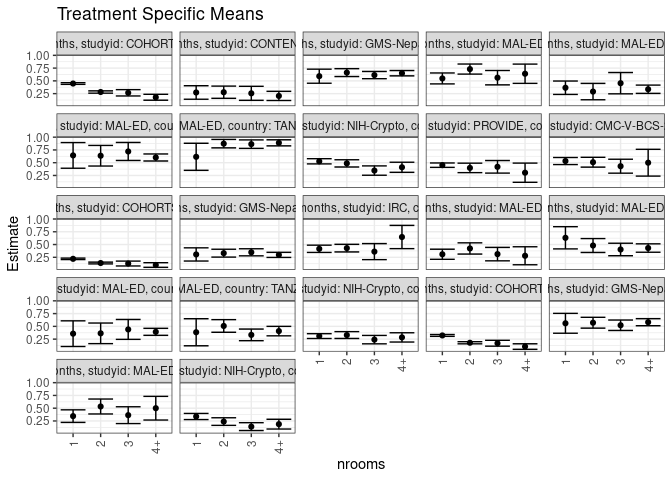

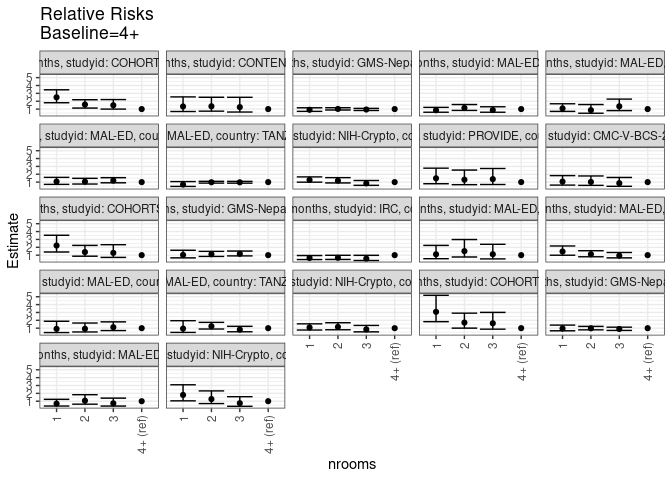

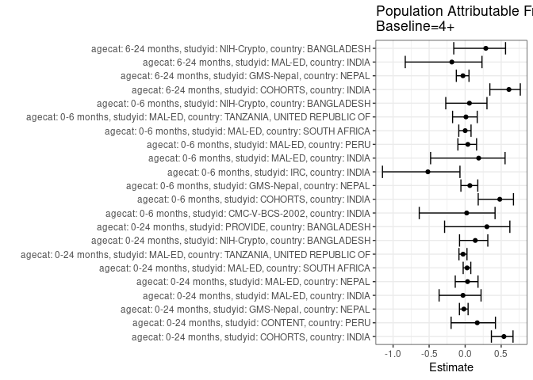

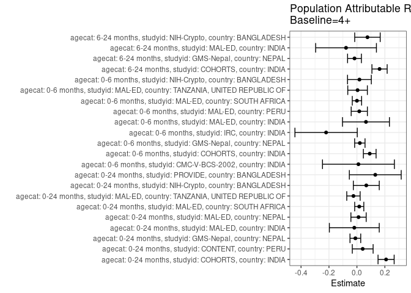

## Results Table

### Parameter: TSM

| agecat | studyid | country | intervention_level | baseline_level | estimate | ci_lower | ci_upper |
| --- | --- | --- | --- | --- | --- | --- | --- |
| 0-24 months | COHORTS | INDIA | 4+ | NA | 0.1792453 | 0.1216304 | 0.2368601 |
| 0-24 months | COHORTS | INDIA | 1 | NA | 0.4478545 | 0.4314231 | 0.4642859 |
| 0-24 months | COHORTS | INDIA | 2 | NA | 0.2818533 | 0.2594825 | 0.3042241 |
| 0-24 months | COHORTS | INDIA | 3 | NA | 0.2666667 | 0.2045932 | 0.3287402 |
| 0-24 months | CONTENT | PERU | 4+ | NA | 0.2051282 | 0.1153079 | 0.2949485 |
| 0-24 months | CONTENT | PERU | 1 | NA | 0.2727273 | 0.1408266 | 0.4046280 |
| 0-24 months | CONTENT | PERU | 2 | NA | 0.2777778 | 0.1580354 | 0.3975201 |
| 0-24 months | CONTENT | PERU | 3 | NA | 0.2564103 | 0.1190495 | 0.3937710 |
| 0-24 months | GMS-Nepal | NEPAL | 4+ | NA | 0.6501548 | 0.5981067 | 0.7022029 |
| 0-24 months | GMS-Nepal | NEPAL | 1 | NA | 0.5918367 | 0.4541224 | 0.7295511 |
| 0-24 months | GMS-Nepal | NEPAL | 2 | NA | 0.6620690 | 0.5850246 | 0.7391134 |
| 0-24 months | GMS-Nepal | NEPAL | 3 | NA | 0.6132597 | 0.5422607 | 0.6842586 |
| 0-24 months | MAL-ED | INDIA | 4+ | NA | 0.6400000 | 0.4514418 | 0.8285582 |
| 0-24 months | MAL-ED | INDIA | 1 | NA | 0.5476190 | 0.4409531 | 0.6542850 |
| 0-24 months | MAL-ED | INDIA | 2 | NA | 0.7307692 | 0.6321233 | 0.8294152 |
| 0-24 months | MAL-ED | INDIA | 3 | NA | 0.5625000 | 0.4218616 | 0.7031384 |
| 0-24 months | MAL-ED | NEPAL | 4+ | NA | 0.3358779 | 0.2548286 | 0.4169271 |
| 0-24 months | MAL-ED | NEPAL | 1 | NA | 0.3653846 | 0.2342254 | 0.4965439 |
| 0-24 months | MAL-ED | NEPAL | 2 | NA | 0.2903226 | 0.1301972 | 0.4504480 |
| 0-24 months | MAL-ED | NEPAL | 3 | NA | 0.4545455 | 0.2460355 | 0.6630554 |
| 0-24 months | MAL-ED | SOUTH AFRICA | 4+ | NA | 0.6020408 | 0.5333816 | 0.6707000 |
| 0-24 months | MAL-ED | SOUTH AFRICA | 1 | NA | 0.6428571 | 0.3913740 | 0.8943403 |
| 0-24 months | MAL-ED | SOUTH AFRICA | 2 | NA | 0.6363636 | 0.4349589 | 0.8377684 |
| 0-24 months | MAL-ED | SOUTH AFRICA | 3 | NA | 0.7200000 | 0.5436522 | 0.8963478 |
| 0-24 months | MAL-ED | TANZANIA, UNITED REPUBLIC OF | 4+ | NA | 0.8888889 | 0.8294995 | 0.9482783 |
| 0-24 months | MAL-ED | TANZANIA, UNITED REPUBLIC OF | 1 | NA | 0.6153846 | 0.3503922 | 0.8803770 |
| 0-24 months | MAL-ED | TANZANIA, UNITED REPUBLIC OF | 2 | NA | 0.8730159 | 0.7906336 | 0.9553982 |
| 0-24 months | MAL-ED | TANZANIA, UNITED REPUBLIC OF | 3 | NA | 0.8636364 | 0.7806778 | 0.9465949 |
| 0-24 months | NIH-Crypto | BANGLADESH | 4+ | NA | 0.4105263 | 0.3115399 | 0.5095127 |
| 0-24 months | NIH-Crypto | BANGLADESH | 1 | NA | 0.5271739 | 0.4761306 | 0.5782172 |

[output cut: 58 more lines]

### Parameter: E(Y)

| agecat | studyid | country | intervention_level | baseline_level | estimate | ci_lower | ci_upper |
| --- | --- | --- | --- | --- | --- | --- | --- |
| 0-24 months | COHORTS | INDIA | NA | NA | 0.3879792 | 0.3749497 | 0.4010086 |
| 0-24 months | CONTENT | PERU | NA | NA | 0.2465116 | 0.1887688 | 0.3042545 |
| 0-24 months | GMS-Nepal | NEPAL | NA | NA | 0.6389685 | 0.6033115 | 0.6746254 |
| 0-24 months | MAL-ED | INDIA | NA | NA | 0.6212766 | 0.5591262 | 0.6834270 |
| 0-24 months | MAL-ED | NEPAL | NA | NA | 0.3474576 | 0.2865784 | 0.4083369 |
| 0-24 months | MAL-ED | SOUTH AFRICA | NA | NA | 0.6186770 | 0.5591785 | 0.6781756 |
| 0-24 months | MAL-ED | TANZANIA, UNITED REPUBLIC OF | NA | NA | 0.8640000 | 0.8214230 | 0.9065770 |
| 0-24 months | NIH-Crypto | BANGLADESH | NA | NA | 0.4775726 | 0.4419904 | 0.5131548 |
| 0-24 months | PROVIDE | BANGLADESH | NA | NA | 0.4357143 | 0.3989556 | 0.4724730 |
| 0-6 months | CMC-V-BCS-2002 | INDIA | NA | NA | 0.5108696 | 0.4597270 | 0.5620121 |
| 0-6 months | COHORTS | INDIA | NA | NA | 0.1906412 | 0.1799566 | 0.2013259 |
| 0-6 months | GMS-Nepal | NEPAL | NA | NA | 0.3180516 | 0.2834770 | 0.3526261 |
| 0-6 months | IRC | INDIA | NA | NA | 0.4264706 | 0.3784228 | 0.4745184 |
| 0-6 months | MAL-ED | INDIA | NA | NA | 0.3446809 | 0.2837868 | 0.4055749 |
| 0-6 months | MAL-ED | PERU | NA | NA | 0.4485294 | 0.3893160 | 0.5077428 |
| 0-6 months | MAL-ED | SOUTH AFRICA | NA | NA | 0.3929961 | 0.3331663 | 0.4528260 |
| 0-6 months | MAL-ED | TANZANIA, UNITED REPUBLIC OF | NA | NA | 0.4120000 | 0.3508656 | 0.4731344 |
| 0-6 months | NIH-Crypto | BANGLADESH | NA | NA | 0.3021108 | 0.2694011 | 0.3348205 |
| 6-24 months | COHORTS | INDIA | NA | NA | 0.2665531 | 0.2530304 | 0.2800757 |
| 6-24 months | GMS-Nepal | NEPAL | NA | NA | 0.5642317 | 0.5153938 | 0.6130696 |
| 6-24 months | MAL-ED | INDIA | NA | NA | 0.4220779 | 0.3438191 | 0.5003367 |
| 6-24 months | NIH-Crypto | BANGLADESH | NA | NA | 0.2628458 | 0.2244546 | 0.3012371 |

### Parameter: RR

| agecat | studyid | country | intervention_level | baseline_level | estimate | ci_lower | ci_upper |
| --- | --- | --- | --- | --- | --- | --- | --- |
| 0-24 months | COHORTS | INDIA | 4+ | 4+ | 1.0000000 | 1.0000000 | 1.0000000 |
| 0-24 months | COHORTS | INDIA | 1 | 4+ | 2.4985567 | 1.8079543 | 3.4529554 |
| 0-24 months | COHORTS | INDIA | 2 | 4+ | 1.5724446 | 1.1292424 | 2.1895938 |
| 0-24 months | COHORTS | INDIA | 3 | 4+ | 1.4877193 | 1.0003793 | 2.2124694 |
| 0-24 months | CONTENT | PERU | 4+ | 4+ | 1.0000000 | 1.0000000 | 1.0000000 |
| 0-24 months | CONTENT | PERU | 1 | 4+ | 1.3295455 | 0.6924138 | 2.5529404 |
| 0-24 months | CONTENT | PERU | 2 | 4+ | 1.3541667 | 0.7325158 | 2.5033826 |
| 0-24 months | CONTENT | PERU | 3 | 4+ | 1.2500000 | 0.6257847 | 2.4968653 |
| 0-24 months | GMS-Nepal | NEPAL | 4+ | 4+ | 1.0000000 | 1.0000000 | 1.0000000 |
| 0-24 months | GMS-Nepal | NEPAL | 1 | 4+ | 0.9103013 | 0.7117308 | 1.1642722 |
| 0-24 months | GMS-Nepal | NEPAL | 2 | 4+ | 1.0183251 | 0.8841866 | 1.1728136 |
| 0-24 months | GMS-Nepal | NEPAL | 3 | 4+ | 0.9432518 | 0.8194042 | 1.0858181 |
| 0-24 months | MAL-ED | INDIA | 4+ | 4+ | 1.0000000 | 1.0000000 | 1.0000000 |
| 0-24 months | MAL-ED | INDIA | 1 | 4+ | 0.8556548 | 0.6010503 | 1.2181094 |
| 0-24 months | MAL-ED | INDIA | 2 | 4+ | 1.1418269 | 0.8257651 | 1.5788615 |
| 0-24 months | MAL-ED | INDIA | 3 | 4+ | 0.8789062 | 0.5972086 | 1.2934780 |
| 0-24 months | MAL-ED | NEPAL | 4+ | 4+ | 1.0000000 | 1.0000000 | 1.0000000 |
| 0-24 months | MAL-ED | NEPAL | 1 | 4+ | 1.0878497 | 0.7058679 | 1.6765416 |
| 0-24 months | MAL-ED | NEPAL | 2 | 4+ | 0.8643695 | 0.4734187 | 1.5781688 |
| 0-24 months | MAL-ED | NEPAL | 3 | 4+ | 1.3533058 | 0.8059220 | 2.2724738 |
| 0-24 months | MAL-ED | SOUTH AFRICA | 4+ | 4+ | 1.0000000 | 1.0000000 | 1.0000000 |
| 0-24 months | MAL-ED | SOUTH AFRICA | 1 | 4+ | 1.0677966 | 0.7104312 | 1.6049262 |
| 0-24 months | MAL-ED | SOUTH AFRICA | 2 | 4+ | 1.0570108 | 0.7550521 | 1.4797280 |
| 0-24 months | MAL-ED | SOUTH AFRICA | 3 | 4+ | 1.1959322 | 0.9127887 | 1.5669057 |
| 0-24 months | MAL-ED | TANZANIA, UNITED REPUBLIC OF | 4+ | 4+ | 1.0000000 | 1.0000000 | 1.0000000 |
| 0-24 months | MAL-ED | TANZANIA, UNITED REPUBLIC OF | 1 | 4+ | 0.6923077 | 0.4477636 | 1.0704085 |
| 0-24 months | MAL-ED | TANZANIA, UNITED REPUBLIC OF | 2 | 4+ | 0.9821429 | 0.8749033 | 1.1025271 |
| 0-24 months | MAL-ED | TANZANIA, UNITED REPUBLIC OF | 3 | 4+ | 0.9715909 | 0.8643055 | 1.0921935 |
| 0-24 months | NIH-Crypto | BANGLADESH | 4+ | 4+ | 1.0000000 | 1.0000000 | 1.0000000 |
| 0-24 months | NIH-Crypto | BANGLADESH | 1 | 4+ | 1.2841416 | 0.9903029 | 1.6651670 |

[output cut: 58 more lines]

### Parameter: PAR

| agecat | studyid | country | intervention_level | baseline_level | estimate | ci_lower | ci_upper |
| --- | --- | --- | --- | --- | --- | --- | --- |
| 0-24 months | COHORTS | INDIA | 4+ | NA | 0.2087339 | 0.1510861 | 0.2663816 |
| 0-24 months | CONTENT | PERU | 4+ | NA | 0.0413834 | -0.0331025 | 0.1158694 |
| 0-24 months | GMS-Nepal | NEPAL | 4+ | NA | -0.0111863 | -0.0495690 | 0.0271964 |
| 0-24 months | MAL-ED | INDIA | 4+ | NA | -0.0187234 | -0.1971951 | 0.1597482 |
| 0-24 months | MAL-ED | NEPAL | 4+ | NA | 0.0115798 | -0.0430333 | 0.0661928 |
| 0-24 months | MAL-ED | SOUTH AFRICA | 4+ | NA | 0.0166362 | -0.0159799 | 0.0492523 |
| 0-24 months | MAL-ED | TANZANIA, UNITED REPUBLIC OF | 4+ | NA | -0.0248889 | -0.0727688 | 0.0229910 |
| 0-24 months | NIH-Crypto | BANGLADESH | 4+ | NA | 0.0670462 | -0.0257350 | 0.1598275 |
| 0-24 months | PROVIDE | BANGLADESH | 4+ | NA | 0.1313665 | -0.0542035 | 0.3169364 |
| 0-6 months | CMC-V-BCS-2002 | INDIA | 4+ | NA | 0.0108696 | -0.2463587 | 0.2680978 |
| 0-6 months | COHORTS | INDIA | 4+ | NA | 0.0916313 | 0.0461849 | 0.1370778 |
| 0-6 months | GMS-Nepal | NEPAL | 4+ | NA | 0.0208380 | -0.0163203 | 0.0579962 |
| 0-6 months | IRC | INDIA | 4+ | NA | -0.2205882 | -0.4435895 | 0.0024130 |
| 0-6 months | MAL-ED | INDIA | 4+ | NA | 0.0646809 | -0.1032443 | 0.2326060 |
| 0-6 months | MAL-ED | PERU | 4+ | NA | 0.0168747 | -0.0410573 | 0.0748067 |
| 0-6 months | MAL-ED | SOUTH AFRICA | 4+ | NA | 0.0001390 | -0.0332432 | 0.0335212 |
| 0-6 months | MAL-ED | TANZANIA, UNITED REPUBLIC OF | 4+ | NA | 0.0045926 | -0.0654787 | 0.0746638 |
| 0-6 months | NIH-Crypto | BANGLADESH | 4+ | NA | 0.0179003 | -0.0672013 | 0.1030018 |
| 6-24 months | COHORTS | INDIA | 4+ | NA | 0.1619019 | 0.1073888 | 0.2164150 |
| 6-24 months | GMS-Nepal | NEPAL | 4+ | NA | -0.0174009 | -0.0668515 | 0.0320497 |
| 6-24 months | MAL-ED | INDIA | 4+ | NA | -0.0779221 | -0.2953456 | 0.1395014 |
| 6-24 months | NIH-Crypto | BANGLADESH | 4+ | NA | 0.0753458 | -0.0158593 | 0.1665510 |

### Parameter: PAF

| agecat | studyid | country | intervention_level | baseline_level | estimate | ci_lower | ci_upper |
| --- | --- | --- | --- | --- | --- | --- | --- |
| 0-24 months | COHORTS | INDIA | 4+ | NA | 0.5380028 | 0.3641105 | 0.6643420 |
| 0-24 months | CONTENT | PERU | 4+ | NA | 0.1678761 | -0.1947556 | 0.4204420 |
| 0-24 months | GMS-Nepal | NEPAL | 4+ | NA | -0.0175068 | -0.0794071 | 0.0408437 |
| 0-24 months | MAL-ED | INDIA | 4+ | NA | -0.0301370 | -0.3615044 | 0.2205812 |
| 0-24 months | MAL-ED | NEPAL | 4+ | NA | 0.0333271 | -0.1373558 | 0.1783957 |
| 0-24 months | MAL-ED | SOUTH AFRICA | 4+ | NA | 0.0268900 | -0.0274276 | 0.0783359 |
| 0-24 months | MAL-ED | TANZANIA, UNITED REPUBLIC OF | 4+ | NA | -0.0288066 | -0.0859740 | 0.0253514 |
| 0-24 months | NIH-Crypto | BANGLADESH | 4+ | NA | 0.1403896 | -0.0777944 | 0.3144055 |
| 0-24 months | PROVIDE | BANGLADESH | 4+ | NA | 0.3014968 | -0.2853100 | 0.6203976 |
| 0-6 months | CMC-V-BCS-2002 | INDIA | 4+ | NA | 0.0212766 | -0.6371469 | 0.4148970 |
| 0-6 months | COHORTS | INDIA | 4+ | NA | 0.4806481 | 0.1812354 | 0.6705690 |
| 0-6 months | GMS-Nepal | NEPAL | 4+ | NA | 0.0655175 | -0.0588990 | 0.1753156 |
| 0-6 months | IRC | INDIA | 4+ | NA | -0.5172414 | -1.1472988 | -0.0720545 |
| 0-6 months | MAL-ED | INDIA | 4+ | NA | 0.1876543 | -0.4794960 | 0.5539660 |
| 0-6 months | MAL-ED | PERU | 4+ | NA | 0.0376224 | -0.1006676 | 0.1585373 |
| 0-6 months | MAL-ED | SOUTH AFRICA | 4+ | NA | 0.0003536 | -0.0883025 | 0.0817876 |
| 0-6 months | MAL-ED | TANZANIA, UNITED REPUBLIC OF | 4+ | NA | 0.0111471 | -0.1744343 | 0.1674033 |
| 0-6 months | NIH-Crypto | BANGLADESH | 4+ | NA | 0.0592507 | -0.2691385 | 0.3026694 |
| 6-24 months | COHORTS | INDIA | 4+ | NA | 0.6073909 | 0.3428302 | 0.7654458 |
| 6-24 months | GMS-Nepal | NEPAL | 4+ | NA | -0.0308400 | -0.1223897 | 0.0532423 |
| 6-24 months | MAL-ED | INDIA | 4+ | NA | -0.1846154 | -0.8311894 | 0.2336600 |
| 6-24 months | NIH-Crypto | BANGLADESH | 4+ | NA | 0.2866541 | -0.1582333 | 0.5606564 |